# L22 - Model Selection

## Lecture Goals

- Understand *bias-variance* trade-off in modeling
- Compare models based on predictive performance
- Perform *variable selection*
- Readings
  - [ISLR](http://www-bcf.usc.edu/~gareth/ISL/) ch 7.1-3

## Model Selection

- **Model Selecion**: process of selecting appropriate model for improving *predictive performance*
  - Different from *model fitting/learning* (i.e. estimating parameters)
- Involves controlling model *complexity*
  - **Regularization** controls *flexibility*
  - **Variable selection** controls *information*

## Model Selection

- Model *too simple* \(\rightarrow\) **Bias**
  - Cannot accurately *describe* relationship
- Model *too complex* \(\rightarrow\) **Variance**
  - Cannot accurately *estimate* relationship

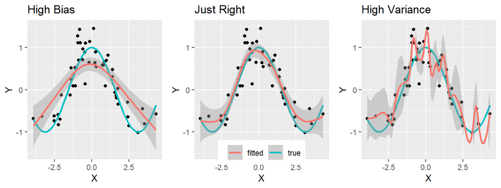

## Predictive Performance

- *In-sample* performance (MSE/\(R^2\)) *always* improves with complexity
  - Want model to perform well *out-of-sample*

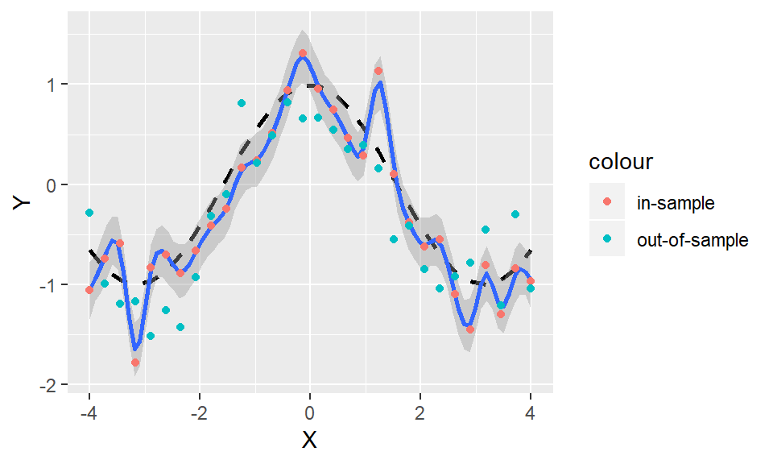

## Bias-Variance Trade-Off

- Another perspective

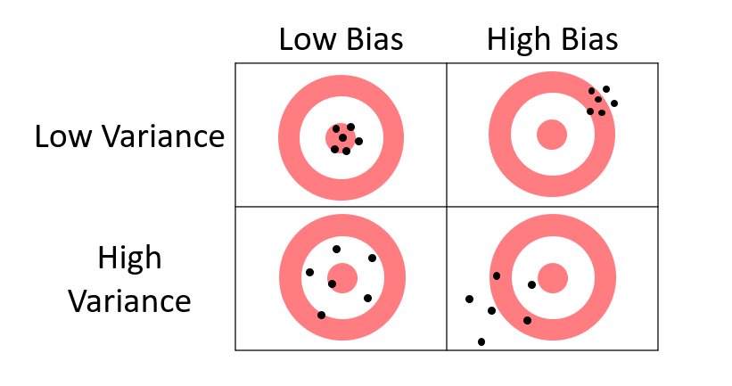

## Bias-Variance Trade-Off

- Another perspective

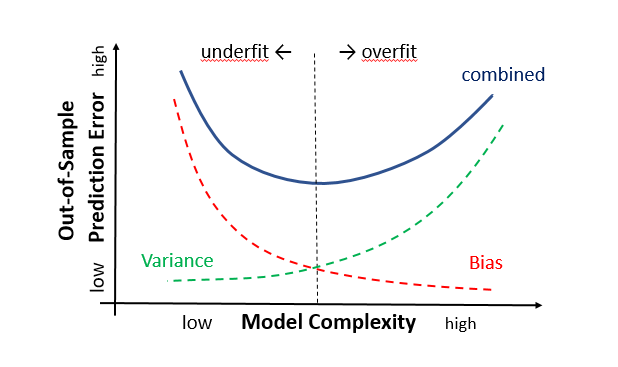

## Regularization

- *Regulatization*: penalize fit with model complexity
  - E.g. select model that minimizes:  
    \[\text{(training error) + (complexity penalty)}\]
- Optimal penalty is unknown, needs to be estimated
- Choose penalty based on out-of-sample performance
  - *Theoretical*: Adjusted \(R^2\), various criteria (AIC/BIC)
  - *Empirical*: Validation set, Cross-Validation

## Example

- Regression tree for hourly earnings (LFS data)
  - In-/out-of-sample performance *without regularization*

```r
train = lfs %>% sample_frac(.70)
test = setdiff( lfs, train)
library(rpart)
tree_out = rpart( hrlyearn ~ immig + age_6 + sex + marstat +
                    educ + naics_21 + noc_10 + noc_40, data = train,
                  control = rpart.control( minsplit = 20, cp = 0))
library(modelr)
train %>% add_predictions( tree_out) %>%
  summarise( sd(hrlyearn - pred)) %>% pull()
## [1] 5.355669
test %>% add_predictions( tree_out) %>%
  summarise( sd(hrlyearn - pred)) %>% pull()
## [1] 8.535006
```

## Example

- In-/out-of- sample performance *with* regularization

```r
xerror = tree_out$cptable[,"xerror"]; xstd = tree_out$cptable[,"xstd"]
cp_ind = min( which( xerror - xstd < min(xerror) ) )
cp_opt = tree_out$cptable[ cp_ind, "CP"]

tree_reg = prune( tree_out, cp = cp_opt )

train %>% add_predictions( tree_reg) %>%
  summarise( sd(hrlyearn - pred)) %>% pull()
## [1] 5.82472
test %>% add_predictions( tree_reg) %>%
  summarise( sd(hrlyearn - pred)) %>% pull()
## [1] 8.344568
```

## Example

- Cross-validated error from `rpart()`

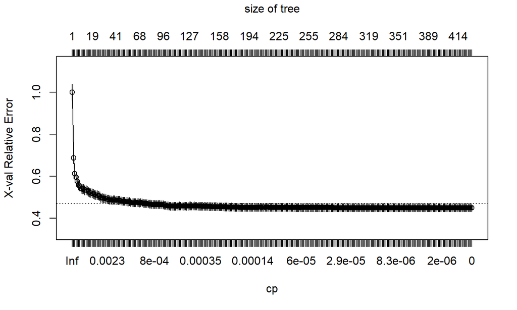

```r
plotcp(tree_out, )
```

## Variable selection

- Adding explanatory variables never hurts in-sample performance
  - Similar to increasing model complexity
  - However, too many variables can harm predictions
- **Variable Selection** chooses *best* subset of variables
  - Optimize w.r.t. out-of-sample performance
- `step()` function in R performs *variable selection*
  - Input *full* model (all possible variables)
  - Output *"optimal"* trimmed down model

## Example

- Add *randomly generated* `X, Z` & fit linear model

```r
lfs_ = lfs %>% mutate( X = rnorm(nrow(lfs)), Z = rnorm(nrow(lfs)))
train_ = lfs_ %>% sample_frac(.50); test_ = setdiff( lfs_, train_)
lm_out = lm( hrlyearn ~ immig + age_6 + sex + marstat +
  educ + noc_10 + X + Z, data = train_)
lm_out %>% glance() %>% pull(r.squared)
## [1] 0.4035515
train_ %>% add_predictions( lm_out) %>%
  summarise( sd(hrlyearn - pred)) %>% pull()
## [1] 7.345609
test_ %>% add_predictions( lm_out ) %>%
  summarise( sd( hrlyearn - pred)) %>% pull()
## [1] 7.373807
```

## Example

- Run through `step()` to remove "redundant" variables

```r
lm_step = step(lm_out, trace = 0)
lm_step$anova # see removed variables
##   Step Df Deviance Resid. Df Resid. Dev      AIC
## 1      NA       NA      3767   204878.4 15208.20
## 2  - X  1 41.00885      3768   204919.4 15206.96
## 3  - Z  1 65.31969      3769   204984.7 15206.17
lm_out %>% glance() %>% pull(r.squared)
## [1] 0.4035515
train_ %>% add_predictions( lm_step ) %>%
  summarise( sd(hrlyearn - pred)) %>% pull()
## [1] 7.347515
test_ %>% add_predictions( lm_step ) %>%
  summarise( sd( hrlyearn - pred)) %>% pull()
## [1] 7.370567
```